# Tools of the Trade

HES 505 Fall 2025: Session 2

Matt Williamson

## Checking in

1. What can I clarify about the course?
2. Are there any challenges you can already see?

## Today’s Plan

- Open Science, reproducibility, and R
- What is a (spatial) data workflow?
- Version control for fun and profit

# A More Democratic Science?

## What is open science?

- Scientific research and its outcomes freely accessible to all
- Accelerate research **AND** improve public trust
- Our focus: Open source software and code

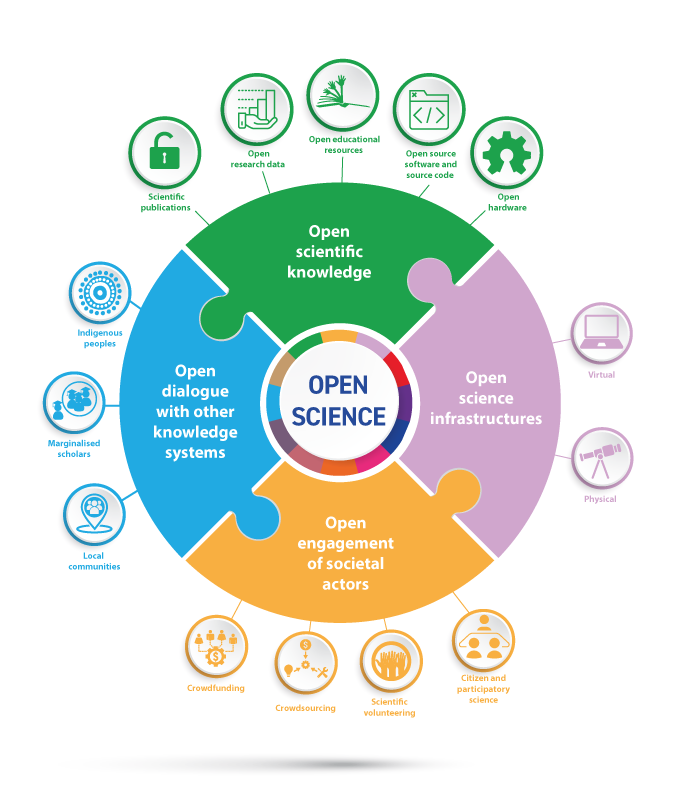

[UNESCO.org](https://commons.wikimedia.org/wiki/File:UNESCO-Open_science-pillars-en.png), [CC BY-SA 4.0](https://creativecommons.org/licenses/by-sa/4.0), via Wikimedia Commons

## Why open source software and code?

- Future-proof: OSS development is fast and ongoing
- Interoperability: Work across hardware types, integrate new software easily
- Free!! (To use and maintain)
- Sharing code and data enables innovation and *reproducibility*

## Why (not) R?

[figure not shown]

- Open Source
- Huge useR community
- Integrated analysis pipelines
- Reproducible workflows

[figure not shown]

- Coding can be hard…
- Memory challenges
- Speed
- Decision fatigue

## Anatomy of an `R` session

- Moving beyond **R**ead-**E**val-**P**rint **L**oops
- `scripts`: contain a record of the code in your analysis and the *objects* you created
- `functions`: perform operations on objects
- `packages`: collections of related functions
- Code
- Plot

```r
library(maps)
library(socviz)
library(tidyverse)
party_colors <- c("#2E74C0", "#CB454A")
us_states <- map_data("state")
election$region <- tolower(election$state)
us_states_elec <- left_join(us_states, election)
p0 <- ggplot(data = us_states_elec,
             mapping = aes(x = long, y = lat,
                           group = group,
                           fill = party))
p1 <- p0 + geom_polygon(color = "gray90",
                        size = 0.1) +
    coord_map(projection = "albers",
              lat0 = 39, lat1 = 45)
p2 <- p1 + scale_fill_manual(values = party_colors) +
    labs(title = "Election Results 2016",
         fill = NULL)
```

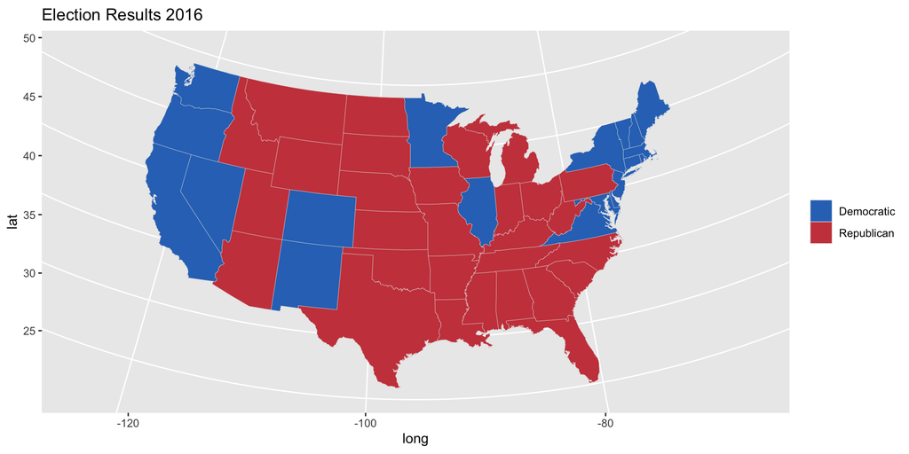

# Reproducible workflows

> Science is a social process!!

## Why Do We Need Reproducibility?

- Noise!!
- Confirmation bias
- Hindsight bias

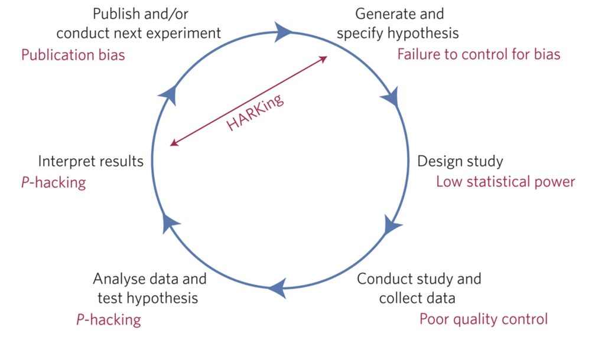

Munafo et al. 2017. Nat Hum Beh.

## What do we mean by reproducible “workflow”?

## Reproducibility and your code

- Scripts: may make your code reproducible (but not your analysis)
- Commenting and [formatting](https://style.tidyverse.org/index.html) can help!
- Think about future you…

````markdown
```{r}
#| eval: false
## load the packages necessary
library(tidyverse)
## read in the data
landmarks_csv <- read_csv("/Users/mattwilliamson/Google Drive/My Drive/TEACHING/Intro_Spatial_Data_R/Data/2023/assignment01/landmarks_ID.csv")

## How many in each feature class
table(landmarks_csv$MTFCC)
```
````

## Reproducible scripts

- Comments explain what the code is doing
- Operations are ordered logically
- Only relevant commands are presented
- Useful object and function names
- Script runs without errors (on your machine and someone else’s)

# Flipping the script

## Toward Efficient Reproducible Workflows

- Scripts can document what you did, but not why you did it!
- Scripts separate your analysis products from your report/manuscript

## What is literate programming?

- Documentation containing code (not vice versa!)
- Direct connection between code and explanation
- Convey meaning to humans rather than telling computer what to do!

## Why literate programming?

- Your analysis scripts **are** computer software
- Integrate math, figures, code, and narrative in one place
- Explaining something helps you learn it

# Introducing Quarto

## What is Quarto?

- A multi-language platform for developing reproducible documents
- A ‘lab notebook’ for your analyses
- Allows transparent, reproducible scientific reports and presentations

## Key components

1. Metadata and global options: YAML
2. Text, figures, and tables: Markdown and LaTeX
3. Code: `knitr` (or `jupyter` if you’re into that sort of thing)

## For this class…

- We’ll use headers to outline the analysis
- We’ll use code chunks for small, self-contained operations
- We’ll create our own functions for repeated operations
- We’ll `knit` our documents into a standalone, readable document

# Version control, reproducibility, and sanity

## Version control in general

- Track changes without version explosion (via `git`)
- Create specific snapshots of a project to facilitate experimentation (via `commit` and `branches`)
- Create centralized backups and ease collaboration (via `GitHub`)

## Version control and reproducibility

- Documenting changes to code, manuscripts, figures increases transparency of the scientific process
- Collaboration with other programmers is easier and less risky
- Automates the sharing of code and original data

## Version control and sanity

- `commit` early, `commit` often
- use sensible messages to remind yourself where you were
- make sure you always have the most up-to-date version
- **It will take some practice to `git` comfortable**